# Coursera Data Science Specialisation: Practical Machine Learning Project

## Background

Using devices such as Jawbone Up, Nike FuelBand, and Fitbit it is now possible to collect a large amount of data about personal activity relatively inexpensively. These type of devices are part of the quantified self movement â a group of enthusiasts who take measurements about themselves regularly to improve their health, to find patterns in their behavior, or because they are tech geeks. One thing that people regularly do is quantify how much of a particular activity they do, but they rarely quantify how well they do it. In this project, your goal will be to use data from accelerometers on the belt, forearm, arm, and dumbell of 6 participants. They were asked to perform barbell lifts correctly and incorrectly in 5 different ways.

## Data Processing

### Obtaining data from sources

The data are downloaded from the given URLs:

```r
training_data_url = "https://d396qusza40orc.cloudfront.net/predmachlearn/pml-training.csv"
test_data_url = "https://d396qusza40orc.cloudfront.net/predmachlearn/pml-testing.csv"
if(!file.exists("train.csv")) {
  download.file(url = training_data_url, destfile = "train.csv")
}
if(!file.exists("test.csv")) {
  download.file(url = testing_data_url, destfile = "test.csv")
}
```

### Cleaning data and feature selection

Since the data contain alot of empty string as values, the data are loaded with `na.strings` specified so that empty values can be properly recognised as `NA`.

```r
train_raw = read.csv("train.csv", na.strings = c("NA", ""))
test_raw = read.csv("test.csv", na.strings = c("NA", ""))
```

In order to get the best features for this study, the following is performed: 1. Removal of indexing columns and timestamps 2. Identification of variables with zero or near zero variance 3. Removal of columns with more than 50% `NA` values

#### 1. Removal of indexing columns and timestamps

The first 7 columns seem like indexes and timestamps as the values increases along with the row number.

```r
index_timestamps_columns = seq(1,7,1)
```

#### 2. Identification of variables with zero or near zero variance

In order to identify these near-zero-variance columns, we need the `caret` package. `columns_to_be_removed` is the variable that store the columns indices.

```r
library(caret)
nzv_columns = nearZeroVar(train_raw, allowParallel = TRUE)
columns_to_be_removed = c(nzv_columns, index_timestamps_columns)
train_first_pass = train_raw[, -columns_to_be_removed]

dim(train_first_pass)
```

```
## [1] 19622   111
```

#### 3. Removal of columns with more than 50% `NA` values

`train_first_pass` can be be further processed to remove columns with more than 50% `NA`.

```r
train_second_pass = train_first_pass[, colSums(is.na(train_first_pass)/dim(train_first_pass)[1]) < 0.5]

train = train_second_pass
dim(train)
```

```
## [1] 19622    53
```

## Model Fitting to predict type of movements

The problem we are tackling is a supervised classification problem, with labelled data set.

With a basic feature vector, we can use it to train a movement classifier. We are going for Random Forest algorithm `rf` to develop the model that will classify the movement data into each of the 5 categories.

We are going to use 70% of the training data to train the model and use the remaining 30% of the training data to do a validation on the model to determine the in and out of sample classification accuracy.

```r
set.seed(1234)
inTrain = createDataPartition(y = train$classe, p = 0.7, list = FALSE)
training = train[inTrain,]
testing = train[-inTrain,]
modelFit = train(classe ~ ., data = training, preProcess = c("center", "scale"), method = "rf")
```

### In-Sample Classification Summary

```r
in_sample = confusionMatrix(training$classe, predict(modelFit, training))
in_sample$table
```

```
##           Reference
## Prediction    A    B    C    D    E
##          A 3906    0    0    0    0
##          B    0 2658    0    0    0
##          C    0    0 2396    0    0
##          D    0    0    0 2252    0
##          E    0    0    0    0 2525
```

```r
in_sample$overall
```

```
##       Accuracy          Kappa  AccuracyLower  AccuracyUpper   AccuracyNull
##      1.0000000      1.0000000      0.9997315      1.0000000      0.2843416
## AccuracyPValue  McnemarPValue
##      0.0000000            NaN
```

```r
in_sample$byClass
```

```
##          Sensitivity Specificity Pos Pred Value Neg Pred Value Prevalence
## Class: A           1           1              1              1  0.2843416
## Class: B           1           1              1              1  0.1934920
## Class: C           1           1              1              1  0.1744195
## Class: D           1           1              1              1  0.1639368
## Class: E           1           1              1              1  0.1838101
##          Detection Rate Detection Prevalence Balanced Accuracy
## Class: A      0.2843416            0.2843416                 1
## Class: B      0.1934920            0.1934920                 1
## Class: C      0.1744195            0.1744195                 1
## Class: D      0.1639368            0.1639368                 1
## Class: E      0.1838101            0.1838101                 1
```

From the summary above, it seems that the `rf` model is able to predict the in-sample data to 100% accuracy!

### Out-of-Sample Classification Summary

```r
out_sample = confusionMatrix(testing$classe, predict(modelFit, testing))
out_sample$table
```

```
##           Reference
## Prediction    A    B    C    D    E
##          A 1673    1    0    0    0
##          B    8 1130    1    0    0
##          C    0    6 1019    1    0
##          D    0    0   10  953    1
##          E    0    0    2    1 1079
```

```r
out_sample$overall
```

```
##       Accuracy          Kappa  AccuracyLower  AccuracyUpper   AccuracyNull
##      0.9947324      0.9933360      0.9925313      0.9964182      0.2856415
## AccuracyPValue  McnemarPValue
##      0.0000000            NaN
```

```r
out_sample$byClass
```

```
##          Sensitivity Specificity Pos Pred Value Neg Pred Value Prevalence
## Class: A   0.9952409   0.9997621      0.9994026      0.9981002  0.2856415
## Class: B   0.9938434   0.9981045      0.9920983      0.9985251  0.1932031
## Class: C   0.9874031   0.9985576      0.9931774      0.9973246  0.1753611
## Class: D   0.9979058   0.9977688      0.9885892      0.9995936  0.1622770
## Class: E   0.9990741   0.9993757      0.9972274      0.9997918  0.1835174
##          Detection Rate Detection Prevalence Balanced Accuracy
## Class: A      0.2842821            0.2844520         0.9975015
## Class: B      0.1920136            0.1935429         0.9959740
## Class: C      0.1731521            0.1743415         0.9929803
## Class: D      0.1619371            0.1638063         0.9978373
## Class: E      0.1833475            0.1838573         0.9992249
```

The out-of-sample accuracy is 99.473237%, which is reasonable given that `rf` is an resource-intensive algorithm (takes a couple of hours to run).

### Cross Validation

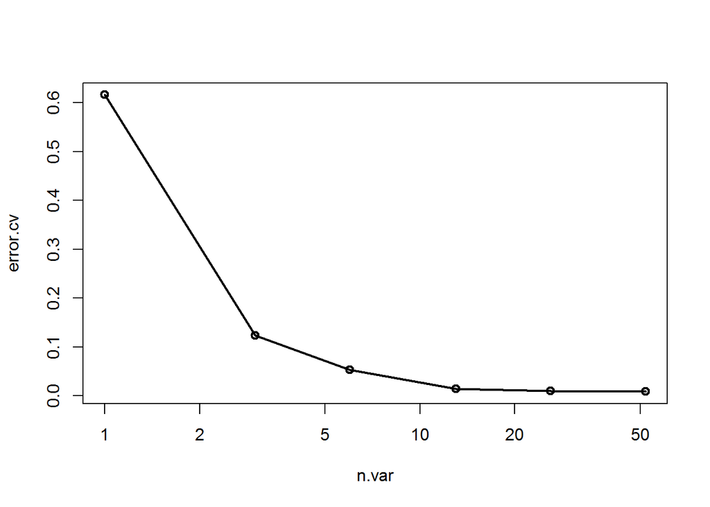

```r
cv_results = rfcv(training[, -53], training$classe, cv.fold = 3)
with(cv_results, plot(n.var, error.cv, log="x", type="o", lwd=2))
```

## Experiment (Submission Exercise)

The model devised in the previous section is then used to tackle the 20 problems provided.

```r
test = test_raw[, colnames(train)[-53]]
test_predictions = predict(modelFit, test)
print(test_predictions)
```

```
##  [1] B A B A A E D B A A B C B A E E A B B B
## Levels: A B C D E
```